# 12_complex_modulus

## 12_complex_modulus

#### Question

1. Let $z_1$ be a complex number with integer components. It is graphed on a [complex plane](https://en.wikipedia.org/wiki/Complex_plane) below, along with a segment connecting it to the origin.

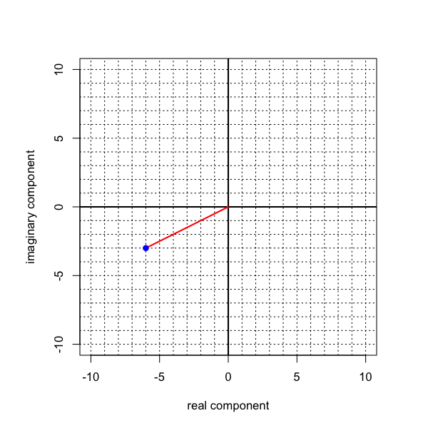

   The [modulus](https://en.wikipedia.org/wiki/Absolute_value#Complex_numbers) of a complex number is analogous to finding distance on a 2D Cartesian plane from the origin to a point. If complex number $z=a+bi$ then its modulus, $|z|$, is calculated with a variation on the distance formula:
   $$|z|=\sqrt{a^2+b^2}$$
   Calculate $|z_1|$. *The tolerance is $\pm 0.1$.*

#### Question

2. Let $z_1$ be a complex number with integer components. It is graphed on a [complex plane](https://en.wikipedia.org/wiki/Complex_plane) below, along with a segment connecting it to the origin.

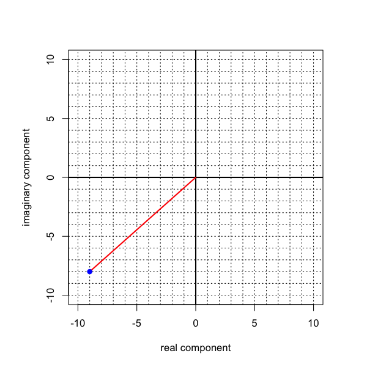

   The [modulus](https://en.wikipedia.org/wiki/Absolute_value#Complex_numbers) of a complex number is analogous to finding distance on a 2D Cartesian plane from the origin to a point. If complex number $z=a+bi$ then its modulus, $|z|$, is calculated with a variation on the distance formula:
   $$|z|=\sqrt{a^2+b^2}$$
   Calculate $|z_1|$. *The tolerance is $\pm 0.1$.*

#### Question

3. Let $z_1$ be a complex number with integer components. It is graphed on a [complex plane](https://en.wikipedia.org/wiki/Complex_plane) below, along with a segment connecting it to the origin.

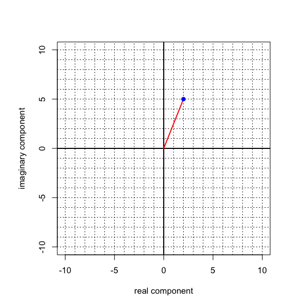

   The [modulus](https://en.wikipedia.org/wiki/Absolute_value#Complex_numbers) of a complex number is analogous to finding distance on a 2D Cartesian plane from the origin to a point. If complex number $z=a+bi$ then its modulus, $|z|$, is calculated with a variation on the distance formula:
   $$|z|=\sqrt{a^2+b^2}$$
   Calculate $|z_1|$. *The tolerance is $\pm 0.1$.*

#### Question

4. Let $z_1$ be a complex number with integer components. It is graphed on a [complex plane](https://en.wikipedia.org/wiki/Complex_plane) below, along with a segment connecting it to the origin.

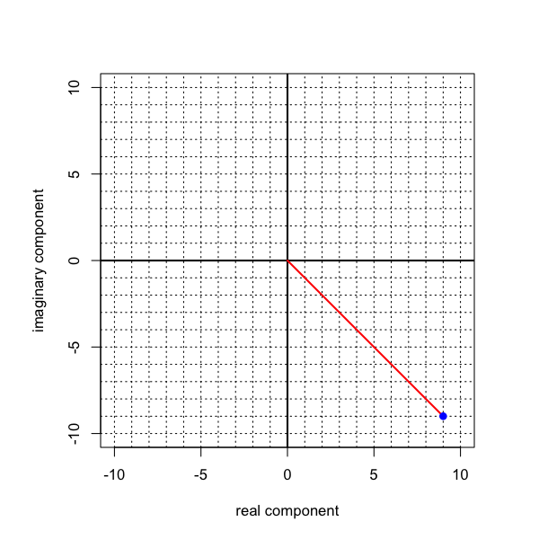

   The [modulus](https://en.wikipedia.org/wiki/Absolute_value#Complex_numbers) of a complex number is analogous to finding distance on a 2D Cartesian plane from the origin to a point. If complex number $z=a+bi$ then its modulus, $|z|$, is calculated with a variation on the distance formula:
   $$|z|=\sqrt{a^2+b^2}$$
   Calculate $|z_1|$. *The tolerance is $\pm 0.1$.*

#### Question

5. Let $z_1$ be a complex number with integer components. It is graphed on a [complex plane](https://en.wikipedia.org/wiki/Complex_plane) below, along with a segment connecting it to the origin.

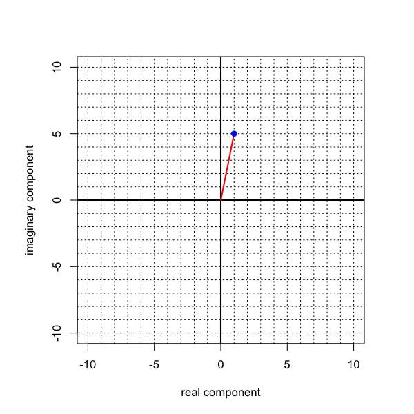

   The [modulus](https://en.wikipedia.org/wiki/Absolute_value#Complex_numbers) of a complex number is analogous to finding distance on a 2D Cartesian plane from the origin to a point. If complex number $z=a+bi$ then its modulus, $|z|$, is calculated with a variation on the distance formula:
   $$|z|=\sqrt{a^2+b^2}$$
   Calculate $|z_1|$. *The tolerance is $\pm 0.1$.*

#### Question

6. Let $z_1$ be a complex number with integer components. It is graphed on a [complex plane](https://en.wikipedia.org/wiki/Complex_plane) below, along with a segment connecting it to the origin.

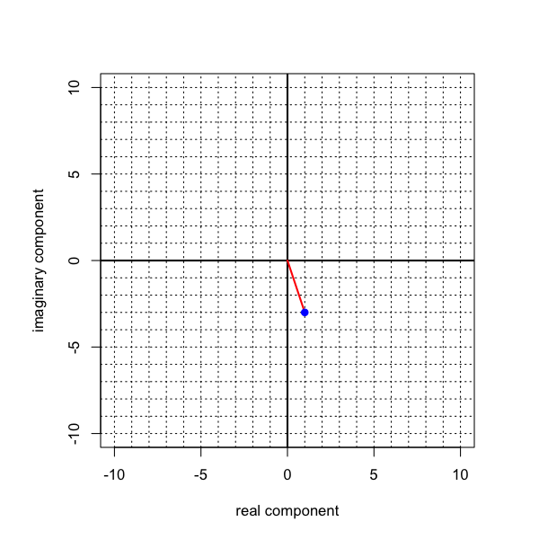

   The [modulus](https://en.wikipedia.org/wiki/Absolute_value#Complex_numbers) of a complex number is analogous to finding distance on a 2D Cartesian plane from the origin to a point. If complex number $z=a+bi$ then its modulus, $|z|$, is calculated with a variation on the distance formula:
   $$|z|=\sqrt{a^2+b^2}$$
   Calculate $|z_1|$. *The tolerance is $\pm 0.1$.*

#### Question

7. Let $z_1$ be a complex number with integer components. It is graphed on a [complex plane](https://en.wikipedia.org/wiki/Complex_plane) below, along with a segment connecting it to the origin.

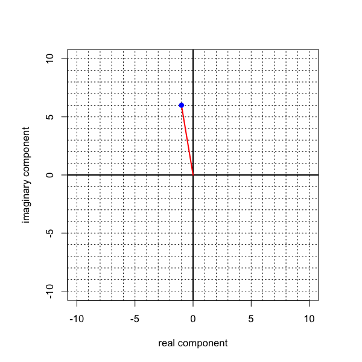

   The [modulus](https://en.wikipedia.org/wiki/Absolute_value#Complex_numbers) of a complex number is analogous to finding distance on a 2D Cartesian plane from the origin to a point. If complex number $z=a+bi$ then its modulus, $|z|$, is calculated with a variation on the distance formula:
   $$|z|=\sqrt{a^2+b^2}$$
   Calculate $|z_1|$. *The tolerance is $\pm 0.1$.*

#### Question

8. Let $z_1$ be a complex number with integer components. It is graphed on a [complex plane](https://en.wikipedia.org/wiki/Complex_plane) below, along with a segment connecting it to the origin.

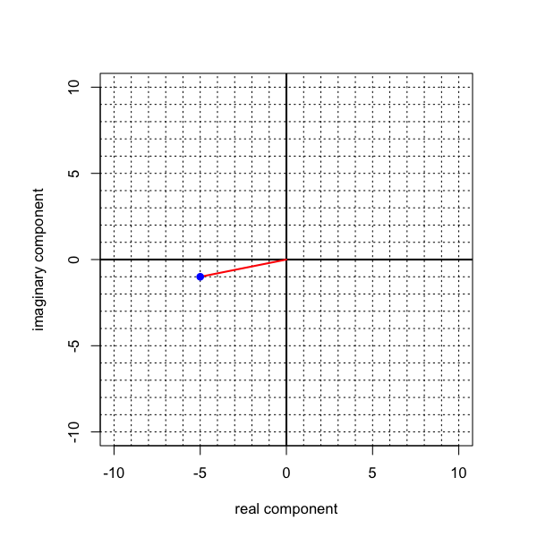

   The [modulus](https://en.wikipedia.org/wiki/Absolute_value#Complex_numbers) of a complex number is analogous to finding distance on a 2D Cartesian plane from the origin to a point. If complex number $z=a+bi$ then its modulus, $|z|$, is calculated with a variation on the distance formula:
   $$|z|=\sqrt{a^2+b^2}$$
   Calculate $|z_1|$. *The tolerance is $\pm 0.1$.*